# Homework 5

## Yue Peng

This jupyter notebook use GFR as your outcome and construct a predictive model for it using

a) stepwise regression;

b) ridge regression;

c) lasso regression

using cross-validation to choose your model form.

```python
%matplotlib inline
import pandas as pd
import numpy as np
import matplotlib.pyplot as plt
import statsmodels.api as sm
# from IPython.display import Markdown, display

from sklearn.model_selection import train_test_split
from sklearn.linear_model import LinearRegression, Lasso, Ridge, RidgeCV, LassoCV
from sklearn.metrics import mean_squared_error
from sklearn.model_selection import KFold, cross_val_score
from sklearn.preprocessing import scale
```

```python
def pretty_print_linear(coefs, names = None, sort = False):
    if names == None:
        names = ["X%s" % x for x in range(len(coefs))]
    lst = zip(coefs, names)
    if sort:
        lst = sorted(lst,  key = lambda x:-np.abs(x[0]))
    return " + ".join("%s \times %s" % (round(coef, 5), name)
                                   for coef, name in lst)

# def printmd(string):
#     display(Markdown(string))
```

We will use the *sklearn* package in order to perform ridge regression and the lasso.

```python
data = pd.read_csv('iodatadev.csv')
```

Loading the data set from two kidney disease studies, and use these variables were given

```python
vars = ["WEIGHT", "BMI", "GFR", "UCRE", "UUN", "UPHO", "SUN", "SCR", "TCHOL", "ALB", "HBA1C", "PHOS",
         "TRIG", "LDL", "HDL", "HB", "MAP", "upro", "BSA", "SODIUM", "GLUC", "BLACK", "HEIGHT", "AGE",
         "FEMALE", "cys", "DBP", "SBP", "CRP", "Diabetes", "hbpstatus"]
```

```python
data = data[vars]
data.shape
```

```
(2749, 31)
```

Before proceeding, let’s first ensure that the missing values in the data set.

```python
for i in vars:
    print('%s has %d missing values' % (i, sum(data[i].isna())))
```

```
WEIGHT has 0 missing values
BMI has 190 missing values
GFR has 0 missing values
UCRE has 630 missing values
UUN has 673 missing values
UPHO has 1888 missing values
SUN has 263 missing values
SCR has 6 missing values
TCHOL has 869 missing values
ALB has 490 missing values
HBA1C has 2106 missing values
PHOS has 819 missing values
TRIG has 2100 missing values
LDL has 2104 missing values
HDL has 2104 missing values
HB has 646 missing values
MAP has 630 missing values
upro has 840 missing values
BSA has 495 missing values
SODIUM has 686 missing values
GLUC has 576 missing values
BLACK has 0 missing values
HEIGHT has 1 missing values
AGE has 0 missing values
FEMALE has 0 missing values
cys has 0 missing values
DBP has 440 missing values
SBP has 440 missing values
CRP has 1018 missing values
Diabetes has 1 missing values
hbpstatus has 1726 missing values
```

We decide to drop some variables due to the large amount of missing data but keeping the original dataset as many as possible

```python
dat = data[["WEIGHT", "BMI", "GFR", "UCRE", "UUN", "SUN", "SCR", "TCHOL", "ALB", "PHOS",
          "HB", "MAP", "upro", "BSA", "SODIUM", "GLUC", "BLACK", "HEIGHT", "AGE",
         "FEMALE", "cys", "DBP", "SBP", "Diabetes"]]
```

```python
dat = dat.dropna()
```

```python
X = dat[["WEIGHT", "BMI", "UCRE", "UUN", "SUN", "SCR", "TCHOL", "ALB", "PHOS",
          "HB", "MAP", "upro", "BSA", "SODIUM", "GLUC", "BLACK", "HEIGHT", "AGE",
         "FEMALE", "cys", "DBP", "SBP", "Diabetes"]]
y = dat["GFR"]
```

```python
print("Finally we keep %.2f of data points with keeping %d/30 predicors" %(X.shape[0]/data.shape[0], X.shape[1]))
```

```
Finally we keep 0.57 of data points with keeping 23/30 predicors
```

## a) Stepwise Regression

We will now perform the stepwise regression in order to predict *GFR* with selected predictors

We first split the samples into a training set and a test set in order to estimate the test error of each regression:

```python
X_train, X_test , y_train, y_test = train_test_split(X, y, test_size=0.3, random_state=123)
```

We will choose predictors stepwisely here by comparing the p-values

```python
def stepwise_selection(X, y,
                       initial_list=[],
                       threshold_in=0.01,
                       threshold_out = 0.05,
                       verbose=True):

    included = list(initial_list)
    while True:
        changed=False
        # forward step
        excluded = list(set(X.columns)-set(included))
        new_pval = pd.Series(index=excluded)
        for new_column in excluded:
            model = sm.OLS(y, sm.add_constant(pd.DataFrame(X[included+[new_column]]))).fit()
            new_pval[new_column] = model.pvalues[new_column]
        best_pval = new_pval.min()
        if best_pval < threshold_in:
            best_feature = new_pval.idxmin()
            included.append(best_feature)
            changed=True
            if verbose:
                print('Add  {:30} with p-value {:.6}'.format(best_feature, best_pval))

        # backward step
        model = sm.OLS(y, sm.add_constant(pd.DataFrame(X[included]))).fit()
        # use all coefs except intercept
        pvalues = model.pvalues.iloc[1:]
        worst_pval = pvalues.max() # null if pvalues is empty
        if worst_pval > threshold_out:
            changed=True
            worst_feature = pvalues.idxmax()
            included.remove(worst_feature)
            if verbose:
                print('Drop {:30} with p-value {:.6}'.format(worst_feature, worst_pval))
        if not changed:
            break
    return included
```

```python
result = stepwise_selection(X_train, y_train)
```

```
Add  cys                            with p-value 8.40897e-253
Add  SUN                            with p-value 2.81868e-15
Add  UCRE                           with p-value 3.22301e-12
Add  BLACK                          with p-value 2.45756e-07
Add  SCR                            with p-value 2.80163e-06
Add  FEMALE                         with p-value 6.4103e-08
Add  ALB                            with p-value 0.000196941
Add  AGE                            with p-value 0.000426735
Add  PHOS                           with p-value 0.00361863
```

```python
kfold = KFold(n_splits=10, random_state=123)
```

```python
model = LinearRegression()
```

```python
model.fit(X_train[result], y_train)
```

```
LinearRegression(copy_X=True, fit_intercept=True, n_jobs=1, normalize=False)
```

```python
print("The test data MSE is %.2f" % (mean_squared_error(y_test, model.predict(X_test[result]))))
print("The test data R-squared is %.2f" % (model.score(X_test[result], y_test)))
```

```
The test data MSE is 150.61
The test data R-squared is 0.72
```

Refit on the whole dataset.

```python
model.fit(X[result], y)
```

```
LinearRegression(copy_X=True, fit_intercept=True, n_jobs=1, normalize=False)
```

```python
# pretty_print_linear(model.coef_, list(X.columns), sort = True)
```

## b) Ridge Regression

We will now perform ridge regression in order to predict *GFR* on the data

```python
lambd = 10**np.linspace(10,-4,500)*0.5
```

```
Text(0,0.5,'weights')
```

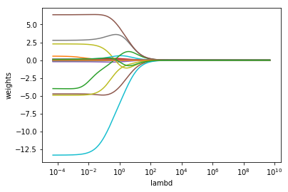

```python
ridge = Ridge(normalize=True)
coefs = []
for a in lambd:
    ridge.set_params(alpha=a)
    ridge.fit(X, y)
    coefs.append(ridge.coef_)
ax = plt.gca()
ax.plot(lambd, coefs)
ax.set_xscale('log')
plt.axis('tight')
plt.xlabel('lambd')
plt.ylabel('weights')
```

We expect the coefficient estimates to be much smaller, in terms of $L_2$ norm, when a large value of alpha is used, as compared to when a small value of alpha is used.

It would be better to use cross-validation to choose the tuning parameter $\lambda$. We can do this using the cross-validated ridge regression function, *RidgeCV( )*. By default, the function performs generalized cross-validation (an efficient form of LOOCV)

```python
print("The range of lambda is from %d to %d " % (min(lambd), max(lambd)))
```

```
The range of lambda is from 0 to 5000000000
```

```python
ridgecv = RidgeCV(alphas=lambd, scoring='neg_mean_squared_error', normalize=True)
```

```python
ridgecv.fit(X_train, y_train)
print( 'Therefore, we can see that the value of alpha that results in the\
    smallest cross-validation error is %.2f. '% (ridgecv.alpha_))
```

```
Therefore, we can see that the value of alpha that results in the smallest cross-validation error is 0.04.
```

Some scores associated with this value of $\lambda$ are

```python
ridge = Ridge(alpha=ridgecv.alpha_, normalize=True)
ridge.fit(X_train, y_train)
print("The test data MSE is %.2f" % (mean_squared_error(y_test, ridge.predict(X_test))))
print("The test data R-squared is %.2f" % (ridge.score(X_test, y_test)))
```

```
The test data MSE is 150.10
The test data R-squared is 0.72
```

Finally, we refit our ridge regression model on the full data set, using the value of $\lambda$ chosen by cross-validation, and examine the coefficient estimates.

```python
ridge.fit(X, y)
```

```
Ridge(alpha=0.036365825565007268, copy_X=True, fit_intercept=True,
   max_iter=None, normalize=True, random_state=None, solver='auto',
   tol=0.001)
```

```python
# pretty_print_linear(ridge.coef_, list(X.columns), sort = True)
```

$$GFR = -12.11437 \times cys + 6.38521 \times BLACK + -4.83569 \times SCR +$$

$$-4.50013 \times FEMALE + 2.99748 \times ALB + 2.00658 \times PHOS + -1.79445 \times BSA +$$

$$-0.24324 \times SUN + 0.22664 \times HB + 0.22337 \times Diabetes + 0.18648 \times UUN +$$

$$0.11935 \times SODIUM + 0.11521 \times BMI + -0.10924 \times AGE + -0.02569 \times HEIGHT +$$

$$0.02269 \times GLUC + -0.02128 \times WEIGHT + -0.00556 \times TCHOL + 0.00328 \times UCRE +$$

$$0.00219 \times MAP + 0.00197 \times DBP + -0.00093 \times SBP + -0.00055 \times upro$$

As expected, none of the coefficients are exactly zero, that is, ridge regression does not perform variable selection.

## Lasso Regression

We will now perform lasso regression in order to predict GFR on the data

We saw that ridge regression with a wise choice of $\lambda$ can outperform least squares. We will see whether the lasso can yield either a more accurate or a more interpretable model than ridge regression in this part.

```
Text(0,0.5,'weights')
```

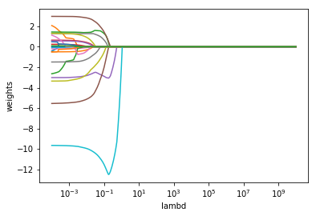

```python
lasso = Lasso(max_iter=10000, normalize=True)
coefs = []
for a in lambd:
    lasso.set_params(alpha=a)
    lasso.fit(scale(X_train), y_train)
    coefs.append(lasso.coef_)
ax = plt.gca()
ax.plot(lambd*2, coefs)
ax.set_xscale('log')
plt.axis('tight')
plt.xlabel('lambd')
plt.ylabel('weights')
```

Notice that in the coefficient plot that depending on the choice of tuning parameter, some of the coefficients are exactly equal to zero. We now perform *10-fold* cross-validation to choose the best alpha, refit the model, and compute the associated test error:

We use the *LassoCV* object that sets its $\lambda$ parameter automatically from the data by internal cross-validation (i.e. it performs cross-validation on the training data it receives).

```python
lassocv = LassoCV(alphas=None, cv=10, max_iter=100000, normalize=True)
```

```python
lassocv.fit(X_train, y_train)
```

```
LassoCV(alphas=None, copy_X=True, cv=10, eps=0.001, fit_intercept=True,
    max_iter=100000, n_alphas=100, n_jobs=1, normalize=True,
    positive=False, precompute='auto', random_state=None,
    selection='cyclic', tol=0.0001, verbose=False)
```

```python
lasso = Lasso(max_iter=10000, normalize=True)
lasso.set_params(alpha=lassocv.alpha_)
lasso.fit(X_train, y_train)
print("The test data MSE is %.2f" % (mean_squared_error(y_test, lasso.predict(X_test))))
print("The test data R-squared is %.2f" % (lasso.score(X_test, y_test)))
```

```
The test data MSE is 149.89
The test data R-squared is 0.72
```

```python
lasso.fit(X, y)
```

```
Lasso(alpha=0.0047921371130301661, copy_X=True, fit_intercept=True,
   max_iter=10000, normalize=True, positive=False, precompute=False,
   random_state=None, selection='cyclic', tol=0.0001, warm_start=False)
```

```python
#pretty_print_linear(lasso.coef_, list(X.columns), sort = True)
```

$$GFR = $-13.64599 \times cys + 5.95952 \times BLACK + -4.30164 \times SCR +$$

$$-3.46714 \times FEMALE + 2.8663 \times ALB + 1.59638 \times PHOS + -0.20604 \times SUN +$$

$$0.12258 \times HB + 0.0848 \times UUN + -0.08286 \times AGE + 0.05791 \times SODIUM +$$

$$-0.01942 \times HEIGHT + 0.01148 \times GLUC + 0.00694 \times BMI + 0.0034 \times UCRE +$$

$$-0.00271 \times TCHOL + -0.00032 \times upro + 0.0 \times WEIGHT + 0.0 \times MAP +$$

$$-0.0 \times BSA + 0.0 \times DBP + 0.0 \times SBP + 0.0 \times Diabetes$$

Also, the lasso has a substantial advantage over ridge regression in that the resulting coefficient estimates are sparse. Here we see that the coefficient estimates of **WEIGHT**, **MAP**, **BSA**, **DBP**, **SBP** and **Diabetes** are exactly zero. The other factors are predictive. This model predicts the data quite well with *MSE = 149.89* and *R-Squared = 0.72*